# R coding library

```r
knitr::opts_chunk$set(fig.width=10, fig.height=8, warning=FALSE, message=FALSE, cache=TRUE, error=T,
                      fig.height=8, fig.width=12)
```

## pivot data

### string data in column names

```r
data("relig_income")
relig_income
```

| religion | <$10k | $10-20k | $20-30k | $30-40k | $40-50k | $50-75k | $75-100k | $100-150k | >150k | Don't know/refused |
| --- | --- | --- | --- | --- | --- | --- | --- | --- | --- | --- |
| Agnostic | 27 | 34 | 60 | 81 | 76 | 137 | 122 | 109 | 84 | 96 |
| Atheist | 12 | 27 | 37 | 52 | 35 | 70 | 73 | 59 | 74 | 76 |
| Buddhist | 27 | 21 | 30 | 34 | 33 | 58 | 62 | 39 | 53 | 54 |
| Catholic | 418 | 617 | 732 | 670 | 638 | 1116 | 949 | 792 | 633 | 1489 |
| Don’t know/refused | 15 | 14 | 15 | 11 | 10 | 35 | 21 | 17 | 18 | 116 |
| Evangelical Prot | 575 | 869 | 1064 | 982 | 881 | 1486 | 949 | 723 | 414 | 1529 |
| Hindu | 1 | 9 | 7 | 9 | 11 | 34 | 47 | 48 | 54 | 37 |
| Historically Black Prot | 228 | 244 | 236 | 238 | 197 | 223 | 131 | 81 | 78 | 339 |
| Jehovah's Witness | 20 | 27 | 24 | 24 | 21 | 30 | 15 | 11 | 6 | 37 |
| Jewish | 19 | 19 | 25 | 25 | 30 | 95 | 69 | 87 | 151 | 162 |

[output cut: 8 more lines]

```r
r2 <- pivot_longer(relig_income,
                   -religion,
                   names_to="income",
                   values_to="count")

r2
```

| religion | income | count |
| --- | --- | --- |
| Agnostic | <$10k | 27 |
| Agnostic | $10-20k | 34 |
| Agnostic | $20-30k | 60 |
| Agnostic | $30-40k | 81 |
| Agnostic | $40-50k | 76 |
| Agnostic | $50-75k | 137 |
| Agnostic | $75-100k | 122 |
| Agnostic | $100-150k | 109 |
| Agnostic | >150k | 84 |
| Agnostic | Don't know/refused | 96 |

[output cut: 170 more lines]

### numeric data in column names

```r
data(billboard)
#head(billboard)
datatable(billboard[1:6,1:6])
```

|  | artist | track | date.entered | wk1 | wk2 | wk3 |
| --- | --- | --- | --- | --- | --- | --- |
| 1 | 2 Pac | Baby Don't Cry (Keep... | 2000-02-26 | 87 | 82 | 72 |
| 2 | 2Ge+her | The Hardest Part Of ... | 2000-09-02 | 91 | 87 | 92 |
| 3 | 3 Doors Down | Kryptonite | 2000-04-08 | 81 | 70 | 68 |
| 4 | 3 Doors Down | Loser | 2000-10-21 | 76 | 76 | 72 |
| 5 | 504 Boyz | Wobble Wobble | 2000-04-15 | 57 | 34 | 25 |
| 6 | 98^0 | Give Me Just One Nig... | 2000-08-19 | 51 | 39 | 34 |

Artist and track stored in rows, week stored in columns, rank stored as values

```r
b2 <- pivot_longer(billboard,
                   -(artist:date.entered),
                   names_to="week",
                   values_to="rank",
                   values_drop_na=T) %>%
  arrange(week, rank)

datatable(b2)
```

[output not shown]

Strip off ‘wk’ from week variable with names_prefix

Convert week to integer with names_ptypes

```r
b3 <- pivot_longer(billboard,
                   -(artist:date.entered),
                   names_to="week",
                   names_prefix="wk",
                   names_ptypes=list(week=integer()),
                   values_to="rank",
                   values_drop_na=T) %>%
  arrange(week, rank)

head(b3)
```

| artist | track | date.entered | week | rank |
| --- | --- | --- | --- | --- |
| Santana | Maria, Maria | 2000-02-12 | 1 | 15 |
| Hanson | This Time Around | 2000-04-22 | 1 | 22 |
| Pink | There U Go | 2000-03-04 | 1 | 25 |
| Carey, Mariah | Crybaby | 2000-06-24 | 1 | 28 |
| Elliott, Missy "Misdemeanor" | Hot Boyz | 1999-11-27 | 1 | 36 |
| Martin, Ricky | She Bangs | 2000-10-07 | 1 | 38 |

### many variables in column names

```r
data(who)

head(who)
```

| country | iso2 | iso3 | year | new_sp_m014 | new_sp_m1524 | new_sp_m2534 | new_sp_m3544 | new_sp_m4554 | new_sp_m5564 | new_sp_m65 | new_sp_f014 | new_sp_f1524 | new_sp_f2534 | new_sp_f3544 | new_sp_f4554 | new_sp_f5564 | new_sp_f65 | new_sn_m014 | new_sn_m1524 | new_sn_m2534 | new_sn_m3544 | new_sn_m4554 | new_sn_m5564 | new_sn_m65 | new_sn_f014 | new_sn_f1524 | new_sn_f2534 | new_sn_f3544 | new_sn_f4554 | … |
| --- | --- | --- | --- | --- | --- | --- | --- | --- | --- | --- | --- | --- | --- | --- | --- | --- | --- | --- | --- | --- | --- | --- | --- | --- | --- | --- | --- | --- | --- | --- |
| Afghanistan | AF | AFG | 1980 | NA | NA | NA | NA | NA | NA | NA | NA | NA | NA | NA | NA | NA | NA | NA | NA | NA | NA | NA | NA | NA | NA | NA | NA | NA | NA | … |
| Afghanistan | AF | AFG | 1981 | NA | NA | NA | NA | NA | NA | NA | NA | NA | NA | NA | NA | NA | NA | NA | NA | NA | NA | NA | NA | NA | NA | NA | NA | NA | NA | … |
| Afghanistan | AF | AFG | 1982 | NA | NA | NA | NA | NA | NA | NA | NA | NA | NA | NA | NA | NA | NA | NA | NA | NA | NA | NA | NA | NA | NA | NA | NA | NA | NA | … |
| Afghanistan | AF | AFG | 1983 | NA | NA | NA | NA | NA | NA | NA | NA | NA | NA | NA | NA | NA | NA | NA | NA | NA | NA | NA | NA | NA | NA | NA | NA | NA | NA | … |
| Afghanistan | AF | AFG | 1984 | NA | NA | NA | NA | NA | NA | NA | NA | NA | NA | NA | NA | NA | NA | NA | NA | NA | NA | NA | NA | NA | NA | NA | NA | NA | NA | … |
| Afghanistan | AF | AFG | 1985 | NA | NA | NA | NA | NA | NA | NA | NA | NA | NA | NA | NA | NA | NA | NA | NA | NA | NA | NA | NA | NA | NA | NA | NA | NA | NA | … |

New prefix is constant so ignore

Second prefix sp/sn/ep/rel is a diagnosis

Third prefix m/f is sex

Fourth prefix is age range

Use multiple values for names_to

Use names_sep or names_pattern to match across variable namesin the columns

```r
w2 <- pivot_longer(who,
                   cols=new_sp_m014:newrel_f65, # cols 5:60
                   names_to = c("diagnosis","sex","age_range"),
                   names_pattern = "new_?(.*)_(.)(.*)",
                   values_to = "count",
                   names_ptypes=list(
                     sex=factor(levels=c("m","f")),
                     age_range=factor(levels=c("014","1524","2534", "3544","4554","5564","65"),
                                      ordered=T)))

head(w2)
```

| country | iso2 | iso3 | year | diagnosis | sex | age_range | count |
| --- | --- | --- | --- | --- | --- | --- | --- |
| Afghanistan | AF | AFG | 1980 | sp | m | 014 | NA |
| Afghanistan | AF | AFG | 1980 | sp | m | 1524 | NA |
| Afghanistan | AF | AFG | 1980 | sp | m | 2534 | NA |
| Afghanistan | AF | AFG | 1980 | sp | m | 3544 | NA |
| Afghanistan | AF | AFG | 1980 | sp | m | 4554 | NA |
| Afghanistan | AF | AFG | 1980 | sp | m | 5564 | NA |

### multiple observations per row

```r
family <- tribble(
  ~family,  ~dob_child1,  ~dob_child2, ~gender_child1, ~gender_child2,
       1L, "1998-11-26", "2000-01-29",             1L,             2L,
       2L, "1996-06-22",           NA,             2L,             NA,
       3L, "2002-07-11", "2004-04-05",             2L,             2L,
       4L, "2004-10-10", "2009-08-27",             1L,             1L,
       5L, "2000-12-05", "2005-02-28",             2L,             1L,
)
family <- family %>% mutate_at(vars(starts_with("dob")), parse_date)
family
```

| family | dob_child1 | dob_child2 | gender_child1 | gender_child2 |
| --- | --- | --- | --- | --- |
| 1 | 1998-11-26 | 2000-01-29 | 1 | 2 |
| 2 | 1996-06-22 |  | 2 | NA |
| 3 | 2002-07-11 | 2004-04-05 | 2 | 2 |
| 4 | 2004-10-10 | 2009-08-27 | 1 | 1 |
| 5 | 2000-12-05 | 2005-02-28 | 2 | 1 |

Family is the id, there are two variables (dob and gender) that repeat across two children (child1 and child2 after underscore).

```r
family %>%
  pivot_longer(
    -family,
    names_to = c(".value", "child"),
    names_sep = "_",
    values_drop_na = TRUE
  )
```

| family | child | dob | gender |
| --- | --- | --- | --- |
| 1 | child1 | 1998-11-26 | 1 |
| 1 | child2 | 2000-01-29 | 2 |
| 2 | child1 | 1996-06-22 | 2 |
| 3 | child1 | 2002-07-11 | 2 |
| 3 | child2 | 2004-04-05 | 2 |
| 4 | child1 | 2004-10-10 | 1 |
| 4 | child2 | 2009-08-27 | 1 |
| 5 | child1 | 2000-12-05 | 2 |
| 5 | child2 | 2005-02-28 | 1 |

Note the use of the ‘sentinel’ of ‘.value’ in the names_to field. Per the documentation for values_to: “If names_to is a character containing the special ‘.value’ sentinel, this value will be ignored, and the name of the value column will be derived from part of the existing column names.”

So, since the sentinel is in the first position, ‘dob’ and ‘gender’ become value columns. And since ‘child’ is in the second position, that becomes a key column.

### MSI use case: employment data from a census table

```r
emp <- readxl::read_excel("data/pivot/Bangladesh 2018 employment, by division.xlsx")

head(emp)
```

| division | status | male_rural | female_rural | total_rural | male_urban | female_urban | total_urban | male_citycorp | female_citycorp | total_citycorp | male_bd | female_bd | total_bd |
| --- | --- | --- | --- | --- | --- | --- | --- | --- | --- | --- | --- | --- | --- |
| Barisal | Employed | 1758 | 668 | 2426 | 313 | 89 | 402 | 100 | 29 | 130 | 2172 | 787 | 2958 |
| Chittagong | Employed | 4516 | 2713 | 7229 | 1104 | 453 | 1557 | 1046 | 400 | 1446 | 6665 | 3566 | 10232 |
| Dhaka | Employed | 8380 | 3517 | 11896 | 2556 | 782 | 3337 | 3614 | 1654 | 5268 | 14549 | 5952 | 20501 |
| Khulna | Employed | 3934 | 1776 | 5710 | 775 | 249 | 1024 | 234 | 67 | 300 | 4943 | 2092 | 7034 |
| Rajshahi | Employed | 4755 | 2971 | 7726 | 1075 | 445 | 1520 | 155 | 60 | 216 | 5986 | 3476 | 9462 |
| Rangpur | Employed | 4449 | 1815 | 6264 | 871 | 230 | 1101 | 97 | 33 | 129 | 5416 | 2078 | 7494 |

This use case follows the example of multiple variables in columns.

First prefix is male/female/total

Second prefix is rural/urban/city corp

```r
emp2 <- emp[,1:11]

emp2L <- pivot_longer(emp2,
                      cols=male_rural:total_citycorp,
                      names_to = c("sex","area"),
                      names_sep = "_",
                      values_to = "count")

head(emp2L)
```

| division | status | sex | area | count |
| --- | --- | --- | --- | --- |
| Barisal | Employed | male | rural | 1758 |
| Barisal | Employed | female | rural | 668 |
| Barisal | Employed | total | rural | 2426 |
| Barisal | Employed | male | urban | 313 |
| Barisal | Employed | female | urban | 89 |
| Barisal | Employed | total | urban | 402 |

### MSI use case: household roster data

```r
roster <- read_csv("data/pivot/hh roster.csv")
str(roster)
```

```
## Classes 'spec_tbl_df', 'tbl_df', 'tbl' and 'data.frame': 1032 obs. of  157 variables:
##  $ m1    : num  1 2 3 4 5 6 7 8 9 10 ...
##  $ B1_1  : num  1 1 1 1 1 1 1 1 1 1 ...
##  $ B3_1  : num  2 1 2 2 2 1 2 1 1 1 ...
##  $ B4_1  : num  2 1 2 2 2 1 2 1 1 1 ...
##  $ B5_1  : num  40 45 40 45 56 63 45 29 45 43 ...
##  $ B6_1  : num  2 1 1 2 2 1 2 1 1 1 ...
##  $ B7_1  : num  1 1 3 1 1 1 1 1 1 1 ...
##  $ B8_1  : num  18 21 20 20 20 24 23 17 19 19 ...
##  $ B9_1  : num  0 12 0 0 0 15 0 15 8 8 ...
##  $ B10_1 : num  1 1 1 1 1 1 1 1 1 2 ...
##  $ B11_1 : num  2 2 2 2 2 2 2 2 2 2 ...
##  $ B12_1 : num  0 0 0 0 0 0 0 0 0 0 ...
##  $ B13_1 : num  0 12 0 0 0 15 0 15 8 8 ...
##  $ B1_2  : num  2 2 2 2 2 2 2 2 2 2 ...
##  $ B3_2  : num  1 2 1 1 1 2 1 2 2 2 ...
##  $ B4_2  : num  1 2 1 1 1 2 1 2 2 2 ...
##  $ B5_2  : num  37 40 19 43 54 60 45 27 41 40 ...
##  $ B6_2  : num  1 2 3 1 1 2 1 2 2 2 ...
##  $ B7_2  : num  1 1 2 1 1 1 1 1 1 1 ...
##  $ B8_2  : num  16 16 0 18 18 21 23 15 20 18 ...
##  $ B9_2  : num  12 0 14 12 14 0 14 6 0 0 ...
##  $ B10_2 : num  1 1 1 1 1 1 1 1 2 2 ...
##  $ B11_2 : num  2 2 2 2 2 2 2 2 2 2 ...
##  $ B12_2 : num  0 0 0 0 0 0 0 0 0 0 ...
##  $ B13_2 : num  12 0 15 12 15 0 15 6 0 0 ...
##  $ B1_3  : num  3 3 3 3 3 3 3 3 3 3 ...
##  $ B3_3  : num  1 2 2 2 1 1 1 2 1 1 ...
##  $ B4_3  : num  1 2 2 2 1 1 1 2 1 1 ...
##  $ B5_3  : num  19 14 16 25 22 23 28 7 20 20 ...
##  $ B6_3  : num  3 3 3 8 3 3 3 3 3 3 ...
##  $ B7_3  : num  2 2 2 1 1 1 1 2 1 1 ...
##  $ B8_3  : num  0 0 0 17 21 19 25 0 18 18 ...
##  $ B9_3  : num  0 6 6 6 12 12 12 1 12 13 ...
##  $ B10_3 : num  1 1 1 1 1 1 1 1 1 2 ...
##  $ B11_3 : num  2 2 2 2 2 2 2 1 2 2 ...
##  $ B12_3 : num  0 0 0 0 0 0 0 2 0 0 ...
##  $ B13_3 : num  0 6 6 6 12 12 12 1 12 15 ...
##  $ B1_4  : num  4 4 4 4 4 4 4 4 4 4 ...
##  $ B3_4  : num  2 1 2 1 2 2 2 1 2 2 ...
```

[output cut: 206 more lines]

```
##   ..   B12_12 = col_double(),
##   ..   B13_12 = col_double(),
##   ..   B1_13 = col_double(),
##   ..   B3_13 = col_double(),
##   ..   B4_13 = col_double(),
##   ..   B5_13 = col_double(),
##   ..   B6_13 = col_double(),
##   ..   B7_13 = col_double(),
##   ..   B8_13 = col_double(),
##   ..   B9_13 = col_double(),
##   ..   B10_13 = col_double(),
##   ..   B11_13 = col_double(),
##   ..   B12_13 = col_double(),
##   ..   B13_13 = col_double()
##   .. )
```

There are 12 variables (B1-B13 but skipping variable 2 which was the hh member name), and variables for up to 13 hh members (1-13 after the underscore). So, this use case follows the pattern of repeating observations per row.

The 12 household roster variables:

```r
key <- read_csv("data/pivot/hh roster key.csv")
hh_names <- unlist(key[,2])
key
```

| variable | name | label |
| --- | --- | --- |
| B1 | mid | hh member id |
| B3 | resp | interview respondent |
| B4 | sex | hh member sex |
| B5 | age | hh member age |
| B6 | relation | hh member relation to head of hh |
| B7 | status | hh member marital status |
| B8 | age_marriage | hh member age at marriage |
| B9 | completed | hh member completed education |
| B10 | madrassa | hh member attended religious school |
| B11 | attending | hh member currently attending school |

[output cut: 2 more lines]

The objective is to pivot the 12 roster variables into long form, and allow for repeating rows for each household member.

```r
hh <- roster %>%
  pivot_longer(
    cols=B1_1:B13_13,
    names_to=c(".value", "mid"),
    names_sep="_",
    values_drop_na=T) %>%
  select(-B1) %>%
  set_names(., nm=c("m1", hh_names))

head(hh)
```

| m1 | mid | resp | sex | age | relation | status | age_marriage | completed | madrassa | attending | hrs | expected |
| --- | --- | --- | --- | --- | --- | --- | --- | --- | --- | --- | --- | --- |
| 1 | 1 | 2 | 2 | 40 | 2 | 1 | 18 | 0 | 1 | 2 | 0 | 0 |
| 1 | 2 | 1 | 1 | 37 | 1 | 1 | 16 | 12 | 1 | 2 | 0 | 12 |
| 1 | 3 | 1 | 1 | 19 | 3 | 2 | 0 | 0 | 1 | 2 | 0 | 0 |
| 1 | 4 | 2 | 2 | 17 | 7 | 2 | 0 | 11 | 1 | 1 | 2 | 11 |
| 1 | 5 | 2 | 2 | 15 | 7 | 2 | 0 | 8 | 1 | 1 | 3 | 8 |
| 1 | 6 | 2 | 2 | 8 | 7 | 2 | 0 | 1 | 1 | 1 | 2 | 1 |

We dropped B1 because this was the hh member id, but this was already created when we specified “mid” in the names_to column.

We now have a dataset where the household identifier (m1) repeats across household members (mid).

## Draw flow diagram based on CONSORT guidelines

MSI empirical studies, especially any studies flowing from specific evaluation designs such as RCTs, diff in diffs, regression discontinuity, etc, will usually benefit from a flow diagram showing the partitioning of the study data into the major disaggregates of interest.

The following code creates a flow diagram based on the [CONSORT](http://www.consort-statement.org/) guidelines for randomized controlled trials in medicine.

```r
build <- build.data.frame(c("e","r","g","a"),
                          list(1,1,"A",1,55),
                          list(1,1,"B",1,83),
                          list("A",0,31),
                          list(1,0,NA,NA,122))
build
```

| e | r | g | a |
| --- | --- | --- | --- |
| 1 | 1 | A | 1 |
| 1 | 1 | A | 1 |
| 1 | 1 | A | 1 |
| 1 | 1 | A | 1 |
| 1 | 1 | A | 1 |
| 1 | 1 | A | 1 |
| 1 | 1 | A | 1 |
| 1 | 1 | A | 1 |
| 1 | 1 | A | 1 |
| 1 | 1 | A | 1 |

[output cut: 281 more lines]

```r
CONSORT_flow_ex1 <- vtree(build,
      keep=list(e="1",
                r="1",
                a="1"),
      horiz=F,
      plain=T,
      showvarnames=F,
      labelnode=list(e=c("Eligible"=1),
                     r=c("Randomized"=1),
                     a=c("Analyzed"=1)),
      title="Assessed for eligibility",
      height=600,
      width=400)

# grVizToPNG(CONSORT_flow_ex1,
#            height=600,
#            width=300,
#            folder="viz/")
```

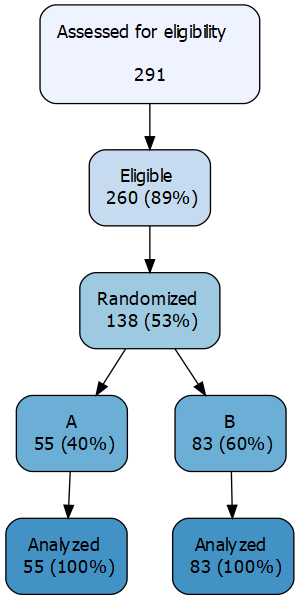

```r
knitr::include_graphics("viz/CONSORT_flow_ex1.png")
```

A more complex example.

```r
FakeRCT
```

| id | eligible | randomized | group | followup | analyzed |
| --- | --- | --- | --- | --- | --- |
| 001 | Eligible | Randomized | B | Followed up | Analyzed |
| 002 | Eligible | Not randomized | NA | NA | NA |
| 003 | Eligible | Randomized | A | Not followed up | NA |
| 004 | Eligible | Randomized | B | Followed up | Analyzed |
| 005 | Eligible | Randomized | A | Followed up | Analyzed |
| 006 | Ineligible | NA | NA | NA | NA |
| 007 | Eligible | Randomized | A | Followed up | Analyzed |
| 008 | Ineligible | NA | NA | NA | NA |
| 009 | Eligible | Randomized | A | Followed up | Analyzed |
| 0010 | Ineligible | NA | NA | NA | NA |

[output cut: 2 more lines]

```r
CONSORT_flow_ex2 <- vtree(FakeRCT,
                          vars = "eligible randomized group followup analyzed",
                          plain=TRUE,
                          follow=list(eligible="Eligible",
                                      randomized="Randomized",
                                      followup="Followed up"),
                          horiz=FALSE,
                          showvarnames=FALSE,
                          title="Assessed for eligibility",
                          summary="id \nid: %list% %noroot%",
                          height=600,
                          width=400)
```

```r
# grVizToPNG(CONSORT_flow_ex2,
#            height=700,
#            width=600,
#            folder="viz/")
```

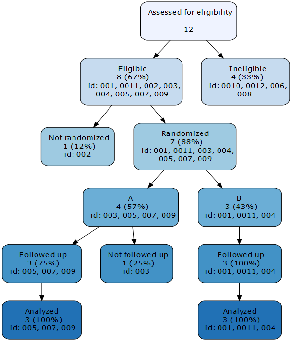

```r
knitr::include_graphics("viz/CONSORT_flow_ex2.png")
```

More explanation and examples may be found in the vtree [vignette](https://cran.r-project.org/web/packages/vtree/vignettes/vtree.html).